# ESM 244 Lab 3

Allison Horst

1/22/2020

# PART 1. Binary Logistic Regression

### a. Read in & combine the penguin data

```r
gentoo <- read_csv("gentoo_lter.csv")
chinstrap <- read_csv("chinstrap_lter.csv")

# Use full_join() to merge them together (keeping everything)
penguins <- full_join(chinstrap, gentoo) %>%
  clean_names() %>%
  mutate(sex = str_to_lower(sex)) %>%
  filter(sex %in% c("male","female"))
```

### b. We should always look at our data first. What do we notice?

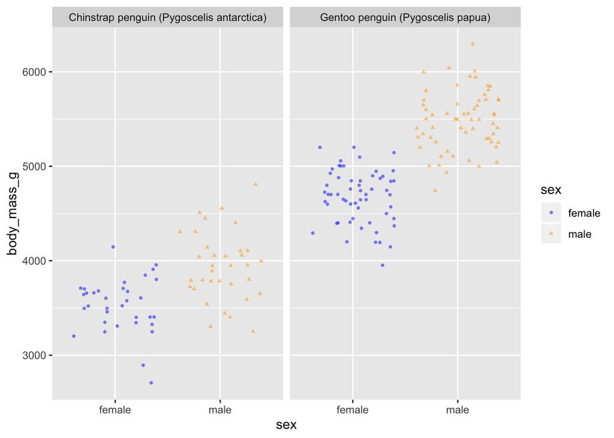

```r
ggplot(penguins, aes(x = sex, y = body_mass_g)) +
  geom_jitter(size = 1,
              alpha = 0.5,
              aes(color = sex,
                  pch = sex)) +
  facet_wrap(~species) +
  scale_color_manual(values = c("blue","orange"))
```

Does it look like, if we knew the sex and body mass of a penguin, we might be able to make some “reasonable” estimate (by probability) of it being an Chinstrap vs. Gentoo? Discuss.

### c. Binomial logistic regression

$$Log Odds (Chinstrap) = \beta_0 + \beta_1(Sex) + \beta_2(BodyMass)$$

We will use ‘family = binomial’ to run binomial logistic regression…otherwise, this looks very similar to other types of regression we’ve already done.

A cool resource (goes deeper into training, testing, etc.): http://r-statistics.co/Logistic-Regression-With-R.html

```r
# First, I am going to manually set an outcome as 0/1

penguin_bin <- penguins %>%
  mutate(sp_binary = case_when(
    species == "Chinstrap penguin (Pygoscelis antarctica)" ~ 1,
    species == "Gentoo penguin (Pygoscelis papua)" ~ 0
  ))

penguin_blr <- glm(sp_binary ~ sex + body_mass_g, family = binomial, data = penguin_bin)

penguin_blr
```

```
##
## Call:  glm(formula = sp_binary ~ sex + body_mass_g, family = binomial,
##     data = penguin_bin)
##
## Coefficients:
## (Intercept)      sexmale  body_mass_g
##    62.91684     11.19523     -0.01557
##
## Degrees of Freedom: 186 Total (i.e. Null);  184 Residual
## Null Deviance:       245.2
## Residual Deviance: 13    AIC: 19
```

```r
summary(penguin_blr)
```

```
##
## Call:
## glm(formula = sp_binary ~ sex + body_mass_g, family = binomial,
##     data = penguin_bin)
##
## Deviance Residuals:
##      Min        1Q    Median        3Q       Max
## -1.80704  -0.01234  -0.00098   0.00258   1.93220
##
## Coefficients:
##              Estimate Std. Error z value Pr(>|z|)
## (Intercept) 62.916845  19.750712   3.186  0.00144 **
## sexmale     11.195233   3.959766   2.827  0.00470 **
## body_mass_g -0.015570   0.004868  -3.198  0.00138 **
## ---
## Signif. codes:  0 '***' 0.001 '**' 0.01 '*' 0.05 '.' 0.1 ' ' 1
##
## (Dispersion parameter for binomial family taken to be 1)
##
##     Null deviance: 245.150  on 186  degrees of freedom
## Residual deviance:  13.003  on 184  degrees of freedom
## AIC: 19.003
##
## Number of Fisher Scoring iterations: 10
```

Hmmm what do these mean? Let’s do some predictions.

See `?predict.glm()` for important information about the `type =` argument!

1. What is the probability that a penguin is a Chinstrap if it weighs 4500 grams and is male?

```r
# Create a data frame with variables `sex` and `body_mass_g`:

df_m4500 <- data.frame(sex = "male", body_mass_g = 4500)

# Find LOG ODDS of being a Chinstrap using predict + type = "link" (the link is log-odds)
m4500_logodds <- predict(penguin_blr, newdata = df_m4500, type = "link")

# Find the actual probability using type = "response":
m4500_prob <- predict(penguin_blr, newdata = df_m4500, type = "response")
m4500_prob # A 98% chance that a male penguin weighing 4500 g is a chinstrap!
```

```
##         1
## 0.9828254
```

2. What is the probability that a penguin is a Chinstrap if it weights 4000 grams and is female?

```r
# Create a data frame with variables `sex` and `body_mass_g`:

df_f4000 <- data.frame(sex = "female", body_mass_g = 4000)

# Find LOG ODDS of being a Chinstrap using predict + type = "link" (the link is log-odds)
f4000_logodds <- predict(penguin_blr, newdata = df_f4000, type = "link")

# Find the actual probability using type = "response":
f4500_prob <- predict(penguin_blr, newdata = df_f4000, type = "response")
f4500_prob
```

```
##         1
## 0.6540249
```

4. Predictions over a whole spectrum of body masses for penguins:

First we’ll make a data frame containing a range of body masses for male / female, then use that to make a bunch of predictions at the same time:

```r
penguins_mock <- data.frame(
  body_mass_g = rep(seq(3000, 6000, length = 200), 2),
  sex = c(rep("male", 200), rep("female", 200))
)

# Check out penguins_mock to see what our new data frame looks like
```

Now, feed that new “mock” data into the model to make predictions for every combination, then make a graph:

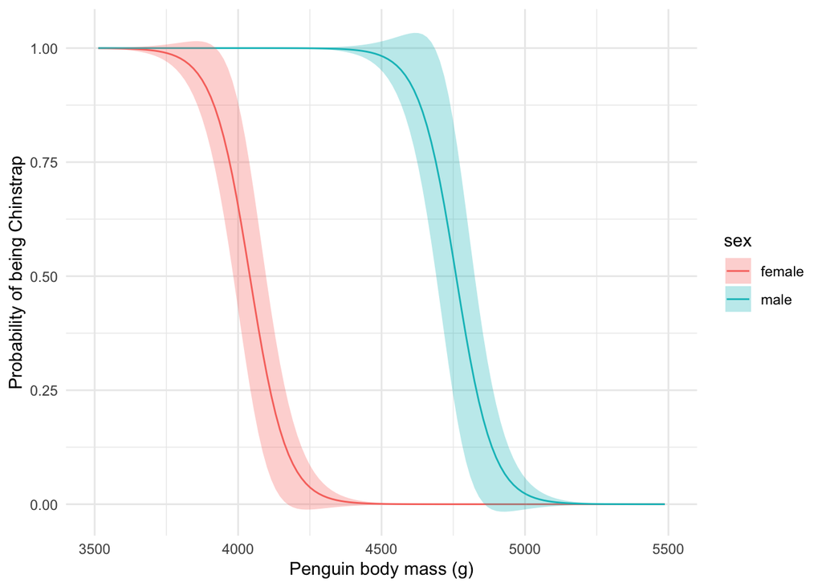

```r
# Get the predicted probabilitys of a chinstrap penguin (+ SEs)
full_predict <- predict(penguin_blr, newdata = penguins_mock, type = "response", se.fit = TRUE)

# Coerce predictions into a data frame, with the mock data + SEs:
final_df <- data.frame(penguins_mock,
                       full_predict$fit,
                       full_predict$se.fit)

colnames(final_df) <- c("penguin_mass", "sex", "probability", "se")

# Check out final_df
# Then plot!

ggplot(data = final_df, aes(x = penguin_mass, y = probability)) +
  geom_line(aes(color = sex)) +
  scale_x_continuous(limits = c(3500, 5500)) +
  geom_ribbon(aes(ymin = probability - se, ymax = probability + se, fill = sex), alpha = 0.3) +
  labs(x = "Penguin body mass (g)",
       y = "Probability of being Chinstrap") +
  theme_minimal()
```

Some questions to think about:

- What are some assumptions we’ve made?
- What are the limitations?
- Do these align with what we’d expect from our data visualization?

# PART 2. (Re)introduction to visualizing spatial data

The `cougar_connections` folder contains spatial data for mountain lion connectivity in the Sierra Nevada foothills. From the researchers: “The least-cost corridors identify the best swath of habitat available for focal species to move from one landscape block to another based on predicted suitable habitat as identified by the northern Sierra Nevada foothills wildlife connectivity project.”

**Citation:** Beier, P., D. R. Majka, and J. S. Jenness. 2007. Conceptual steps for designing wildlife corridors.

Link to project report: https://nrm.dfg.ca.gov/FileHandler.ashx?DocumentID=85358

### Step 1. Read in the data!

Use `sf::read_sf()` to read in the spatial data together!

```r
cougars <- read_sf(dsn = here("cougar_connections"), layer = "ds1014") %>%
  clean_names()
```

Notice that the last column is “geometries” - that contains the *sticky* spatial data - meaning that we can wrangle & work with our data just like we’ve done before, but the spatial information will stick to it!

### STEP 2: Practice some spatial wrangling with sticky geometries

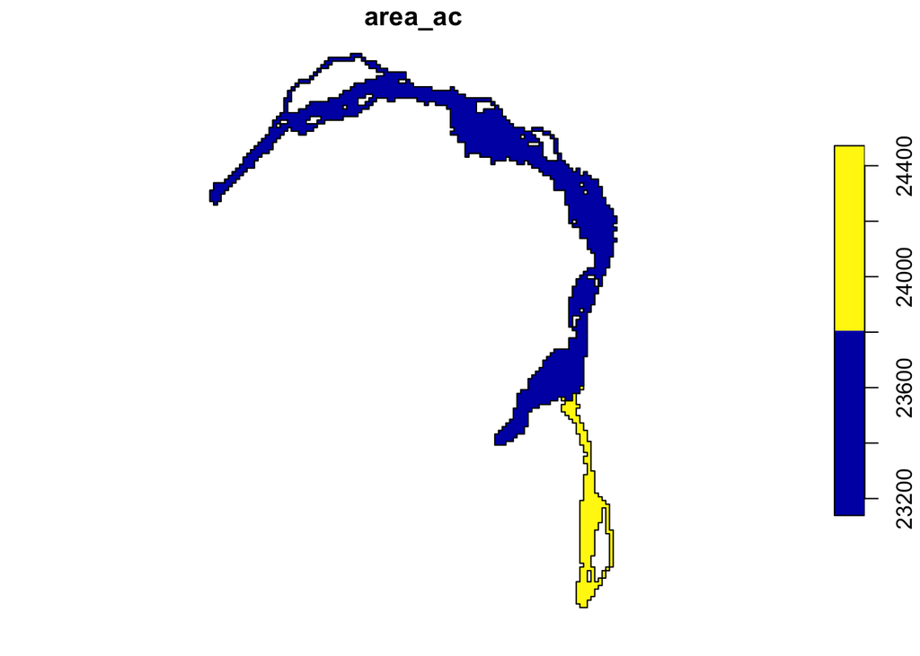

```r
# Use wrangling functions as usual (+ pipe, etc!)
large_corridors <- cougars %>%
  filter(area_ac > 20000) %>%
  select(area_ac)

# Look at 'large_corridors' data frame and see that the geometries column still appears, even though we didn't explicitly select it. Cool sf magic!

# We can even use the base plot() function to see what's happening (careful of doing this if we have multiple attributes):
plot(large_corridors)
```

Let’s create a different subset from the original data that contains the following variables:

- elev_mean (mean elevation)
- ecoregs (eco-regions)
- pc_urban (percent urban area in polygon)

```r
cougar_sub <- cougars %>%
  select(elev_mean, ecoregs, pc_urban)
```

### STEP 3. Visualizing spatial polygons with `geom_sf`

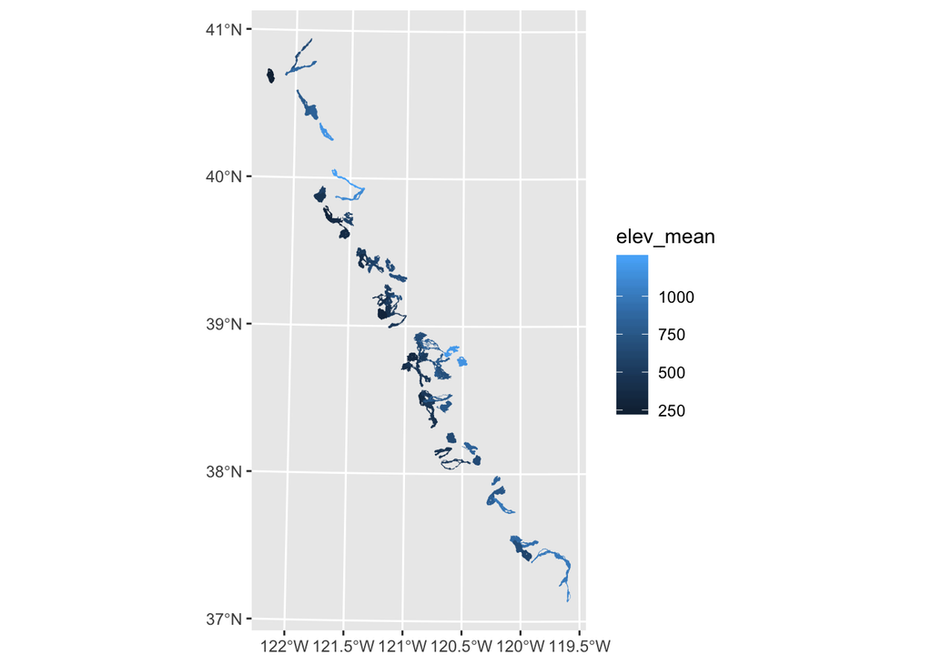

```r
ggplot(data = cougar_sub) +
  geom_sf(aes(fill = elev_mean), color = NA)
```

### STEP 4. Actually give it some context & interactivity!

We can use `tmap` to make a static or interactive plot over an existing basemap.

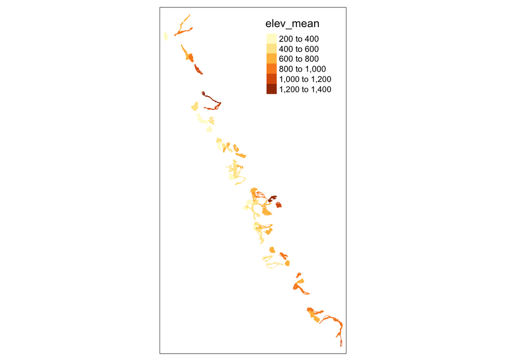

```r
# This will make a stationary (non-interactive) plot
tmap_mode("plot") # switch to "view" to make interactive!

#
tm_shape(cougar_sub) +
  tm_fill("elev_mean")
```

OK maybe not the most inspiring thing, but it works…now let’s change the view mode:

```r
tmap_mode("view") # Set to interactive viewing
tm_shape(cougar_sub) +
  tm_fill("elev_mean") +
  tm_basemap("Stamen.Terrain")
```

[interactive chart not shown]

See http://leaflet-extras.github.io/leaflet-providers/preview for a preview of basemaps you can add with `tm_basemap`!

Try out some different basemaps and test interactivity, and see that it’s maintained when you knit!